# Text Analysis

Author

Zoe Zhou

Published

March 17, 2025

## Overview

In this project, I analyze text data from the New York Times API to explore the language used in articles about **coral bleaching**. The analysis includes word frequency, sentiment analysis, and emotional tone detection. The goal is to understand how this topic is framed in the media, Specifically, we aim to:

- Identify the most frequently used words in the articles.
- Analyze the sentiment (positive or negative) associated with the articles.
- Examine the emotional tone (e.g., joy, sadness, anger) conveyed in the text.

### Data

The data is obtained from the **New York Times Article Search API**, which provides metadata and text snippets (e.g., headlines, lead paragraphs) for articles.

**Citation:** New York Times API, Article Search API, accessed March 17, 2025. (2025, March 17). https://developer.nytimes.com/docs/articlesearch-product/1/routes/articlesearch.json

### Outline

1. Data Query
2. Text Preprocessing
3. Word Frequency Analysis
4. Sentiment Analysis
5. Emotional Tone Analysis

## Set up

Load in libraries and obtain API key from NYT Developers account to access data.

```r
library(jsonlite) #convert results from API queries into R-friendly formats
library(tidyverse)
library(tidytext) #text data management and analysis
library(ggplot2) #plot word frequencies and publication dates
library(ggwordcloud)

API_KEY <- "nGF1sqQpicrPJGzZNThJ1VfNKj4BoGnH"
```

## Data Query

We query the New York Times API to retrieve articles on coral bleaching published between January 2024 and March 2025. The query URL is constructed using the `fromJSON()` function, which handles the API request and response.

```r
# Set some parameters for query
term1 <- "coral bleaching"
#term2 <- "$bleaching" # use $ to string together separate terms
begin_date <- "20240101"
end_date <- "20250301"

# Construct the query url using API operators
baseurl <- paste0("http://api.nytimes.com/svc/search/v2/articlesearch.json?q=",URLencode(term1),"&begin_date=",begin_date,"&end_date=",end_date,"&facet_filter=true&api-key=",API_KEY, sep="")

# Get initial query
initialquery <- fromJSON(baseurl)
#initialquery
```

```r
maxPages <- 4
#initiate a list to hold results of our for loop
pages <- list()
for(i in 0:maxPages){
  nytSearch <- fromJSON(paste0(baseurl, "&page=", i), flatten = TRUE) %>% data.frame()
  message("Retrieving page ", i)
  pages[[i+1]] <- nytSearch
  Sys.sleep(12) }
```

The New York Times API provides only the first paragraph of each article. We tokenize this text into individual words using tidytext::unnest_tokens() and clean it by removing stop words, numbers, and possessive suffixes.

```r
# Combine to dataframe
nytDat <- bind_rows(pages)
#class(nytDat)
#names(nytDat)
#head(nytDat[,1:6])
# Acquire words from text
tokenized <- nytDat %>%
  filter(response.docs.news_desk!="Styles") %>%
  unnest_tokens(word, response.docs.lead_paragraph) #word is the new column, paragraph is the source

# Load stop words dataset
data("stop_words")

# Remove stop words from the tokenized data
tokenized <- tokenized %>%
  anti_join(stop_words)

# Clean the tokens by removing numbers and possessive suffixes
tokenized <- tokenized %>%
  mutate(
    clean = str_remove_all(word, "[:digit:]") %>%  # Remove all numbers
            gsub("’s", "", .)                     # Remove possessive suffixes
  )

# Remove rows with empty strings in the 'clean' column
tokenized <- tokenized %>%
  filter(clean != "")
```

## Word Frequency Analysis

We calculate the frequency of words in the dataset and visualize the most common words.

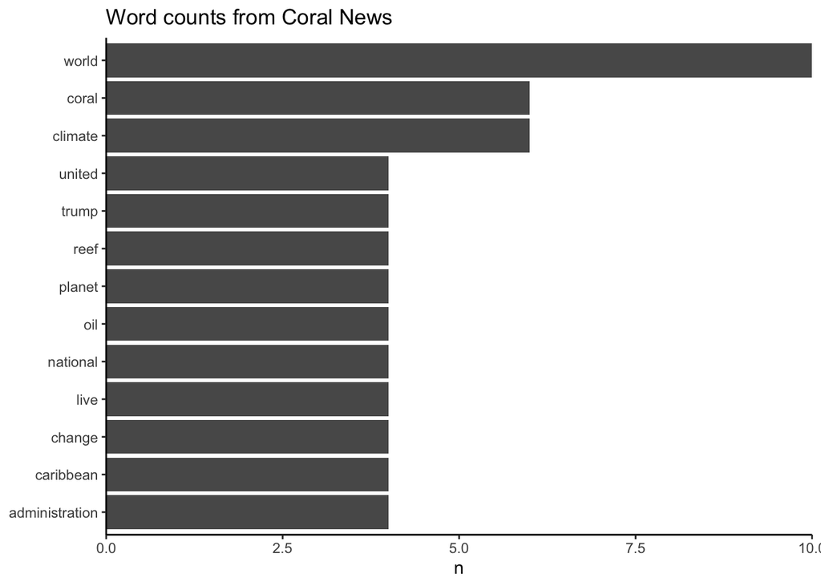

```r
# Graph word counts
tokenized %>%
  count(clean, sort = TRUE) %>%
  filter(n > 3) %>%
  mutate(clean = reorder(clean, n)) %>%
  ggplot(aes(n, clean)) +
  geom_col() +
  scale_x_continuous(expand = c(0, 0)) +
  labs(y = NULL,
       title="Word counts from Coral News")+
  theme_classic()
```

## Sentiment Analysis

We use the Bing Sentiment Lexicon to classify words as positive or negative and calculate the sentiment score for each article.

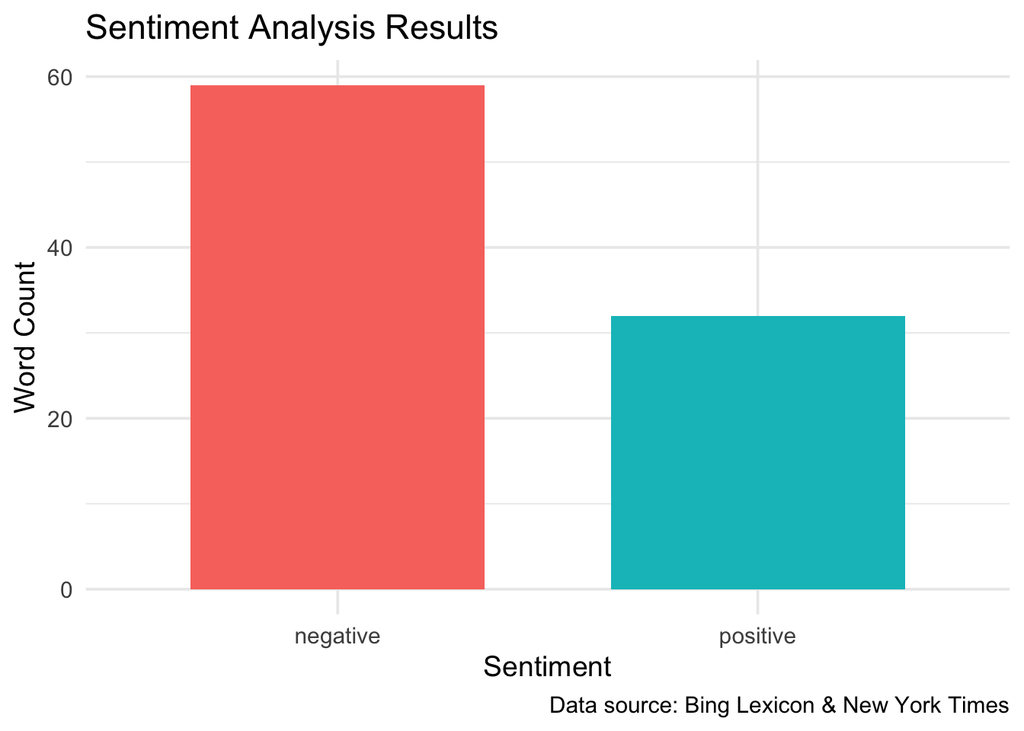

```r
# Load the bing sentiment lexicon from tidytext
bing_sent <-  get_sentiments("bing")
#head(bing_sent)

# Get numerical score of text
sent_words <- tokenized %>%
  inner_join(bing_sent, by='word') %>%
  mutate(sent_num = case_when(sentiment =='negative'~-1,
                              sentiment =='positive'~1))

# Find summary of the sentiments
bing_counts <- sent_words %>%
  count(sentiment)

# Plot sentiment summary
ggplot(data=bing_counts, aes(x=sentiment, y=n, fill = sentiment))+
  geom_col(show.legend = FALSE,width = 0.7)+
  scale_fill_manual(values = c("positive" = "#00BFC4", "negative" = "#F8766D"))+
  labs(
    title = "Sentiment Analysis Results",
    x = "Sentiment",
    y = "Word Count",
    caption = "Data source: Bing Lexicon & New York Times"
  ) +
  theme_minimal(base_size = 14)
```

```r
# Calculate mean sentiment
sent_article <- sent_words %>%
  group_by(response.docs._id) %>%
  count(sentiment) %>%
  pivot_wider(names_from = sentiment, values_from=n)%>%
  mutate(polarity = positive-negative)


# Calculate the mean sentiment score
mean_polarity <- mean(sent_article$polarity, na.rm = TRUE)

# print the result
cat("\n",
    "==============================\n",
    "Mean Sentiment Score for Coral News:\n",
    sprintf("%.2f", mean_polarity),  # Format the score to 2 decimal places
    "\n==============================\n")
```

```
 ==============================
 Mean Sentiment Score for Coral News:
 -0.20
==============================
```

### Emotional Tone Analysis

We use the NRC Lexicon to analyze the emotional tone of the articles, identifying words associated with emotions like joy, sadness, anger, and trust.

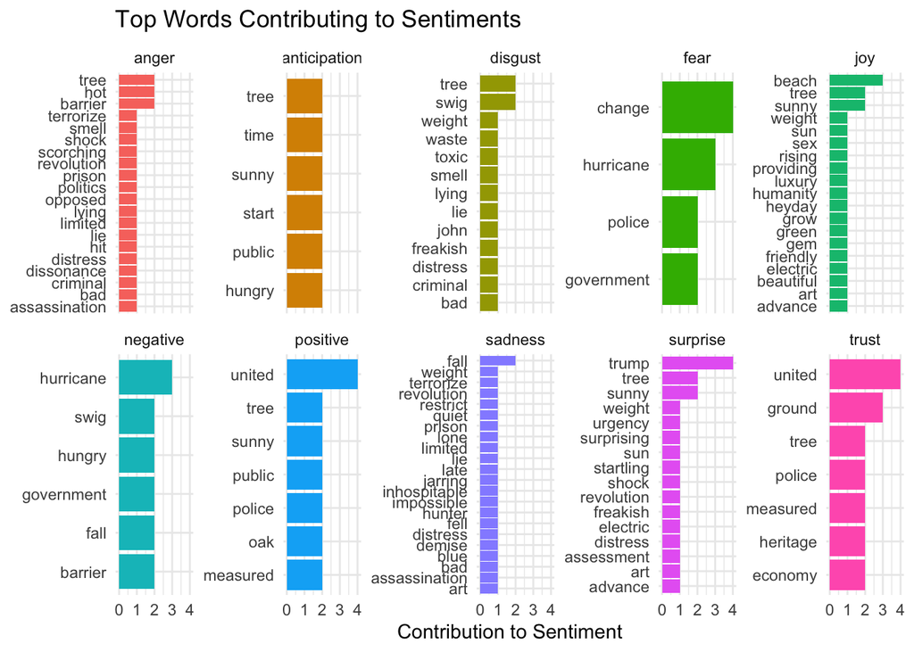

```r
nrc_sent <- get_sentiments('nrc')
nrc_word_counts <- tokenized %>%
  inner_join(nrc_sent) %>%
  count(word, sentiment, sort=T)

# nrc_word_counts

nrc_word_counts %>%
  group_by(sentiment) %>%
  slice_max(n,n=4)%>%
  ungroup() %>%
  mutate(word = reorder(word, n))%>%
  ggplot(aes(n,word,fill = sentiment))+
  geom_col(show.legend = FALSE) +
  facet_wrap(~sentiment, scales="free_y", ncol=5)+
  labs(title="Top Words Contributing to Sentiments",
       x='Contribution to Sentiment', y = NULL)+
  theme_minimal()
```

### Conclusion

This analysis provides insights into how coral bleaching is discussed in the media. The sentiment analysis reveals the overall tone of the articles is negative, while the emotional tone analysis highlights the specific emotions associated with the topic.